# Práctico 3 - Estadística

## Tabla de Datos

```r
load('datos.RData')
mean_aprobadas <- mean(est$Aprobadas)
var_aprobadas <- var(est$Aprobadas)
# Funcion de Estandar Error
se <- function(x) sqrt(var(x)/length(x))

se_aprobadas = se(est$Aprobadas)
```

## Problema 1

**a)** Media puntual de Aprobadas, muestra = 5

**b)** Varianza puntual de Aprobadas, muestra = 6.40855106888361

**c)** Error Estandar de Aprobadas, muestra = 0.123232057410634

**d)**

```r
p_nivel_confianza = 0.90   #nivel de confianza dado
d_datos <- est$Aprobadas #No hace falta, solo para debug
N <- length(d_datos)   #tamaño muestra
alfa <- 1 - p_nivel_confianza #alfa
es <- sd(est$Aprobadas) # error estandar
Q <- qnorm(1-alfa/2) #qnorm en P(Z > a) = k Devuelve el a para la probabilidad k.
intervalo <- c(mean(d_datos)-Q*es/sqrt(N), mean(d_datos)+Q*es/sqrt(N) ) #Formula : x +- Z (o/raiz(n)
```

El intervalo es:

```r
intervalo
```

```
[1] 4.797301 5.202699
```

[1] es son los límites inferiores y superiores del intervalo

```r
p_nivel_confianza = 0.95   #nivel de confianza dado
d_datos <- est$Aprobadas #No hace falta, solo para debug
N <- length(d_datos)   #tamaño muestra
alfa <- 1 - p_nivel_confianza #alfa
es <- sd(est$Aprobadas) # error estandar
Q <- qnorm(1-alfa/2) #qnorm en P(Z > a) = k Devuelve el a para la probabilidad k.
intervalo <- c(mean(d_datos)-Q*es/sqrt(N), mean(d_datos)+Q*es/sqrt(N) ) #Formula : x +- Z (o/raiz(n)
```

El intervalo es:

```r
intervalo
```

```
[1] 4.75847 5.24153
```

[1] es son los límites inferiores y superiores del intervalo

## Problema 2.a

Recodificar la variable a 0 y 1

```r
est$CompB[est$Complementaria == "Sí"] <- 1
est$CompB[est$Complementaria != "Sí"] <- 0
table(est$Complementaria, est$CompB)
```

```
       0   1
  No 306   0
  Sí   0 116
```

Frecuencia de datos de Complementaria, P(x=1) y P(x=0).

**Frecuencia Absoluta**

```r
adatos <- table(est$CompB)
adatosp <- prop.table(adatos)
adatos
```

```
  0   1
306 116
```

**Frecuencia Relativa**

```r
adatosp
```

```
        0         1
0.7251185 0.2748815
```

Para obtener el n se utiliza:

para poblaciones finitas [2.1] :
$$\frac{N Z_{a} ^{2} p q}{e^{2} \left ( N - 1 \right )Z_{a} ^{2} p q}$$

Y para poblaciones infinitas o con N desconocido[2.2] :
$$\frac{Z_{a} ^{2} p q}{e^{2}}$$

Fuente: Daniel WW (1999). Biostatistics: A Foundation for Analysis in the Health Sciences. 7th edition. New York: John Wiley & Sons. Pag 180.

En este caso no se conoce N (tamaño de la población) por que se tomará la fórmula [2.2]

```r
confianza <- 0.95
error <- 0.02
v_z <- qnorm(confianza)
p <- adatosp[2]

q <- adatosp[1]

v_z ^ 2 * p * q / error^2
```

```
       1
1348.184
```

## Problema 2.b

Tomando la formula [2.2]:
$$n = \frac{Z_{a} ^{2} p q}{e^{2}}$$

Se deduce que :
$$e = \sqrt{ \frac{Z_{a} ^{2} p q}{n}}$$

```r
confianza <- 0.95
nmuestra = 422
v_z <- qnorm(confianza)
p <- adatosp[2]

q <- adatosp[1]

sqrt(v_z ^ 2 * p * q / nmuestra)
```

```
         1
0.03574772
```

## Problema 3

Separar la tabla de datos en dos. Los que para que siempre estudian grupalmente y el resto.

```r
datos_siempre <- subset(est, est$EstudioGrupal == "Casi siempre")
datos_otros <- subset(est, est$EstudioGrupal != "Casi siempre")
```

## Problema 3.a

La varianza de materias aprobadas para el grupo de Casi Siempre estudian grupalmente es:

```r
var(datos_siempre$Aprobadas)
```

```
[1] 6.03617
```

La varianza de materias aprobadas para el resto del grupo es:

```r
var(datos_otros$Aprobadas)
```

```
[1] 6.451174
```

## Problema 3.b

La fórmula para calcular el intervalo de confianza para un cociente de varianza es:

$$\frac{S_{1}^{2} / S_{2}^{2} }{F_{\alpha/2}} < \frac{\sigma_{1}^{2}}{\sigma_{2}^{2}} < \frac{S_{1}^{2} / S_{2}^{2} }{F_{1-\alpha/2}}$$
O de otra forma tomando los parámetros de la distribuciôn F (mas clara para mi):

$$\frac{S_{1}^{2}}{S_{2}^{2}} \frac{1 }{F_({\alpha/2}, n_{1}-1,n_{2}-1)} < \frac{\sigma_{1}^{2}}{\sigma_{2}^{2}} < \frac{S_{1}^{2}}{S_{2}^{2}} {F_({1-\alpha/2}, n_{2}-1,n_{1}-1)}$$

No pude, en este tiempo, encontrar la fórmula de distribuciôn F tanto en R. O mejor dicho no pude hacer coindir los cálculos manuales (sin la tabla en papel) con el procedimiento de R para calcular el intervalo, por que los valores de F me difieren, incluso en páginas en línea que hacen el cálculo.

Por eso, directamente tomo el siguiente procedimiento de R, que lo calcula automáticamente.

```r
var.test(datos_siempre$Aprobadas, datos_otros$Aprobadas, conf.level = 0.9)
```

```
    F test to compare two variances

data:  datos_siempre$Aprobadas and datos_otros$Aprobadas
F = 0.93567, num df = 102, denom df = 318, p-value =
0.702
alternative hypothesis: true ratio of variances is not equal to 1
90 percent confidence interval:
 0.7249297 1.2333072
sample estimates:
ratio of variances
           0.93567
```

Esto dice que el el intervalo de confianza al 90% del cociente de las dos varianza se encuentra en el intervalo [0,7249297, 1,2333072]

## Problema 3.c

Respuesta: Dado que es un cociente, y en el intervalo calculado el valor 1 se encuentra comprendido podemos decir que las varianzas son similares o muy parecidas.

## Problema 4.a

Calcular el intervalo de de medias para los dos grupos anteriores.

```r
t.test(datos_siempre$Aprobadas, datos_otros$Aprobadas, conf.level = 0.9, var.equal = TRUE)
```

```
    Two Sample t-test

data:  datos_siempre$Aprobadas and datos_otros$Aprobadas
t = 2.2036, df = 420, p-value = 0.02809
alternative hypothesis: true difference in means is not equal to 0
90 percent confidence interval:
 0.1585417 1.1001247
sample estimates:
mean of x mean of y
 5.475728  4.846395
```

Respuesta: está claro que el primer intervalo presentado en el cuadro del ejercicio corresponde al intervalo que se ha calculado, con lo cual lo representa. El intervalo es [0.1585417,1.1001247]

## Problema 4.b

Si fuese iguales el intervalo calculado anteriormente tendría que contemplar el valor 0. Como está escluido el valor 0, que significaría que en un 90% de probabilidad de que sean iguales, se concluye que el promedio de materias aprobadas entre los dos grupos no es igual.

## Problema 5.a

```r
cov(est$Aprobadas, est$RedesSociales)
```

```
[1] 0.5771971
```

Es positiva. Lo único que podemos decir es que hay una relación directa.

## Problema 5.b

```r
cor(est$Aprobadas, est$RedesSociales)
```

```
[1] 0.03966919
```

El valor de correlación en 0.039669

Lo primero que nos dice al ser positivo que la aumentan conjuntamente (relación directa). En cuanto al valor significa que hay escaza relación entre ambas variables.

## Problema 5.c y 5.d

Grafico de dispersion y de la linea de regresión

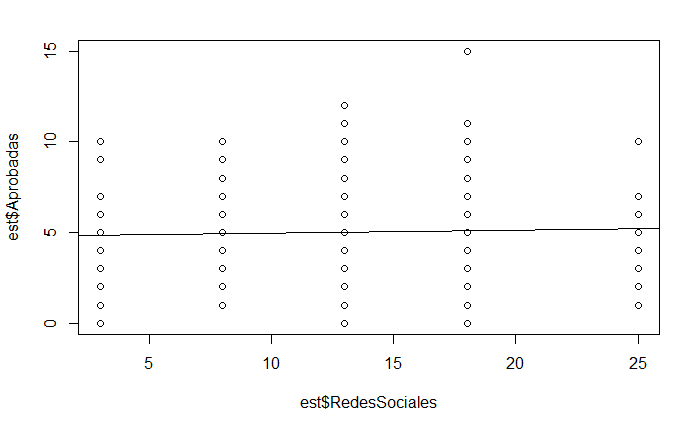

```r
plot( est$RedesSociales, est$Aprobadas)
abline(lsfit(est$RedesSociales, est$Aprobadas))
```

```r
modelo <- lm(est$Aprobadas ~ est$RedesSociales)
```

Ahora los parámetros del modelo:

```r
modelo
```

```
Call:
lm(formula = est$Aprobadas ~ est$RedesSociales)

Coefficients:
      (Intercept)  est$RedesSociales
          4.77804            0.01747
```

El modelo que
$$MateriaAprobadas = \alpha + \beta \cdot RedesSociales$$
Por lo que según los coeficientes son
$$\alpha = 4.77804 \:y\: \beta = 0.01747$$

**Interpretación**: $\alpha$ es es valor que tendría Materias Aprobadas si un individuo estuviera 0 horas de Redes Sociales. Es la ordenada al origen de la pendiente. $\beta$, por otro lado es la pendiente de la recta de regresión lineal simple, y es cuanto se incrementaría Materias Aprobadas ante cada incremento en Redes Sociales. Digo incremento pues el valor de Beta es positvo.

## Problema 6.a a 6.b

Grafico de dispersion y de la linea de regresión según los datos de la tabla enviada.

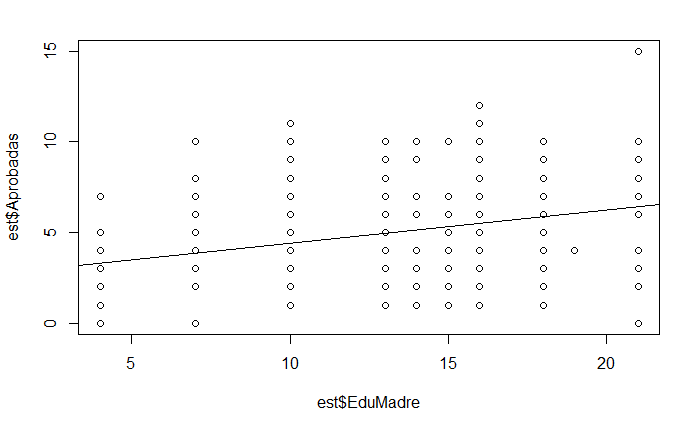

```r
plot( est$EduMadre, est$Aprobadas)
abline(lsfit(est$EduMadre, est$Aprobadas))
```

```r
modelo <- lm(est$Aprobadas ~ est$EduMadre )
```

Los parámetros de la regresión son:

```r
summary(modelo)
```

```
Call:
lm(formula = est$Aprobadas ~ est$EduMadre)

Residuals:
    Min      1Q  Median      3Q     Max
-6.4200 -1.8387 -0.2855  1.5019  8.5800

Coefficients:
             Estimate Std. Error t value Pr(>|t|)
(Intercept)   2.54803    0.39915   6.384 4.58e-10 ***
est$EduMadre  0.18438    0.02868   6.429 3.50e-10 ***
---
Signif. codes:  0 ‘***’ 0.001 ‘**’ 0.01 ‘*’ 0.05 ‘.’ 0.1 ‘ ’ 1

Residual standard error: 2.418 on 420 degrees of freedom
Multiple R-squared:  0.08959,   Adjusted R-squared:  0.08742
F-statistic: 41.33 on 1 and 420 DF,  p-value: 3.496e-10
```

**a)** Segun los datos de la tabla adjunta al ejercicio esto fueron mi valores. El
$$\alpha = 2.54803$$
,

Que es la ordenada al origen de la regresión y el valor que tendría si la madre no tuviera grados de educación.

El
$$\beta = 0.18438$$
que signifca que hay una relación directa, aumenta una y otra, en una proporción de 0.18438 por cada año de educación de la madre. Y es la pendiente de la recta de regresión.

**b)** En este punto, se puede decir que los años de educación de la madre afecta muy poco en la cantidad de materias aprobadas de su hijo. Para asegurar eso es necesario el coeficiene de correlación.

Que es:

```r
cor(est$EduMadre,est$Aprobadas)
```

```
[1] 0.2993197
```

Este coeficiente no dice con certeza (que va de -1 a 1), que hay poco correlación entre ambas variables. Pero si que si ambas crecen o decrecen conjuntamente.

**c)**

Si la regresión arrojó la siguiente relación:

$$MateriaAprobadas = 2.54803 + 0.18438 \cdot AñosEducaciónMadre$$
Entonces 10 años de educación de la madre se esperaría que un su hijo estudiante aprube:

```r
 2.54803 + 0.18438 * 10
```

```
[1] 4.39183
```

**d)** El
$$R^2 = (Coeficiente de Correlación) ^ 2$$

En este caso es :

```r
varz = cor(est$EduMadre,est$Aprobadas)
varz ^ 2
```

```
[1] 0.0895923
```

$R^2$ es 0.089 que es la proporción que puede explicar el modelo de regresión lineal entre los años de estudio de la madre y la cantidad de materias aprobadas de su hijo. En porcentje sería de 8.9%.